# scRNA-seq Analysis of SARS-CoV-2 Infection

James Hughes

2026-03-19

```r
knitr::opts_chunk$set(
  echo = TRUE,
  warning = FALSE,
  message = FALSE,
  dev = "png",
  dpi = 150,
  cache = FALSE
)
# Reproducibility
set.seed(1234)

# Parallel-safe RNG (important with future)
RNGkind("L'Ecuyer-CMRG")

# setwd("C:/Users/james/OneDrive/Desktop/Covid 19/scRNA-seq")

results_dir <- "results"
exports_dir <- "data"

dir.create(results_dir, showWarnings = FALSE)
dir.create(exports_dir, showWarnings = FALSE)

save_plot <- function(plot_obj, filename, width = 7, height = 5, dpi = 200) {
  ggplot2::ggsave(
    filename = file.path(results_dir, filename),
    plot = plot_obj,
    width = width,
    height = height,
    dpi = dpi,
    bg = "white"
  )
}
```

# Introduction

Single-cell RNA sequencing (scRNA-seq) enables transcriptional profiling at the resolution of individual cells, allowing identification of distinct cell populations and their gene expression programmes. In this study, scRNA-seq was used to investigate the peripheral immune response in a publicly available PBMC dataset associated with SARS-CoV-2 infection. The aim was to identify major immune cell populations, define cluster-specific marker genes, and determine which cell types may underlie the immune-related signals observed in bulk RNA-seq studies.

# Methods

## Setup

```r
library(Seurat)
library(dplyr)
library(ggplot2)
library(Matrix)
library(patchwork)
library(DropletUtils)
library(tidyverse)
library(SingleR)
library(harmony)
library(future)
library(celldex)

available_workers <- parallel::detectCores(logical = FALSE)
available_workers <- if (is.na(available_workers)) 2 else available_workers
marker_workers <- max(1, min(2, available_workers - 1))
future::plan(sequential)
options(future.globals.maxSize = 8 * 1024^3)
```

### Load Data

```r
counts <- Read10X(data.dir = "C:/Users/james/OneDrive/Desktop/Covid 19/scRNA-seq")

dim(counts)
```

```
## [1] 33538 85144
```

```r
obj <- CreateSeuratObject(
  counts = counts,
  project = "COVID_PBMC_scRNA",
  min.cells = 3,
  min.features = 200
)

obj
```

```
## An object of class Seurat
## 23311 features across 76529 samples within 1 assay
## Active assay: RNA (23311 features, 0 variable features)
##  1 layer present: counts
```

```r
dim(obj)
```

```
## [1] 23311 76529
```

```r
genes_initial <- nrow(obj)
cells_initial <- ncol(obj)
```

### Quality Control

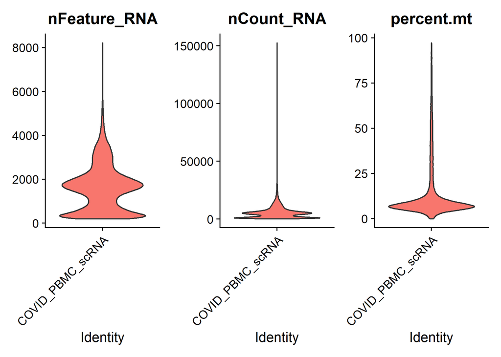

```r
obj[["percent.mt"]] <- PercentageFeatureSet(obj, pattern = "^MT-") ## Calculate % of mitochondrial gene expression
qc_plot <- VlnPlot(
  obj,
  features = c("nFeature_RNA", "nCount_RNA", "percent.mt"),
  pt.size = 0
) ## Shows distribution for each cell
save_plot(qc_plot, "qc_violin.png", width = 10, height = 4)
qc_plot
```

Quality control (QC) was performed to remove low-quality and artefactual cells from the dataset. Raw scRNA-seq data can include empty droplets, dying cells, and doublets, which may distort downstream analysis. Cells were assessed using the number of detected genes (nFeature_RNA), total RNA counts (nCount_RNA), and the percentage of mitochondrial expression (percent.mt). Low gene counts indicate poor-quality cells, unusually high gene or RNA counts may reflect doublets, and elevated mitochondrial expression is consistent with stressed or dying cells.

### Filtering

```r
obj <- subset(obj,
  subset = nFeature_RNA > 300 &
           nFeature_RNA < 6000 &
           nCount_RNA < 40000 &
           percent.mt < 15
)

obj
```

```
## An object of class Seurat
## 23311 features across 56736 samples within 1 assay
## Active assay: RNA (23311 features, 0 variable features)
##  1 layer present: counts
```

```r
cells_filtered <- ncol(obj)
genes_filtered <- nrow(obj)
```

Cells were filtered based on quality control metrics to remove low-quality and artefactual observations. Thresholds were applied to retain cells with a sufficient number of detected genes, while excluding cells with unusually high gene or RNA counts indicative of doublets. Additionally, cells with elevated mitochondrial gene expression were removed, as this reflects cellular stress or degradation. This filtering step ensures that downstream analyses are performed on high-quality, biologically meaningful single cells.

### Gene Filtering

```r
counts_mat <- GetAssayData(obj, layer = "counts")
keep_genes <- Matrix::rowSums(counts_mat > 0) >= 10
obj <- subset(obj, features = rownames(obj)[keep_genes])

genes_filtered <- nrow(obj)
```

Genes detected in fewer than 10 cells were removed prior to normalisation. This reduces the number of extremely sparse features, which improves memory usage and runtime while retaining the genes that contribute most meaningfully to downstream clustering and marker detection.

### Normalisation

```r
obj <- NormalizeData(
  obj,
  normalization.method = "LogNormalize",
  scale.factor = 10000,
  block.size = 2000,
  verbose = FALSE
)
```

The data were normalised to account for differences in sequencing depth across cells, allowing gene expression levels to be compared across the dataset.

### Variable Features

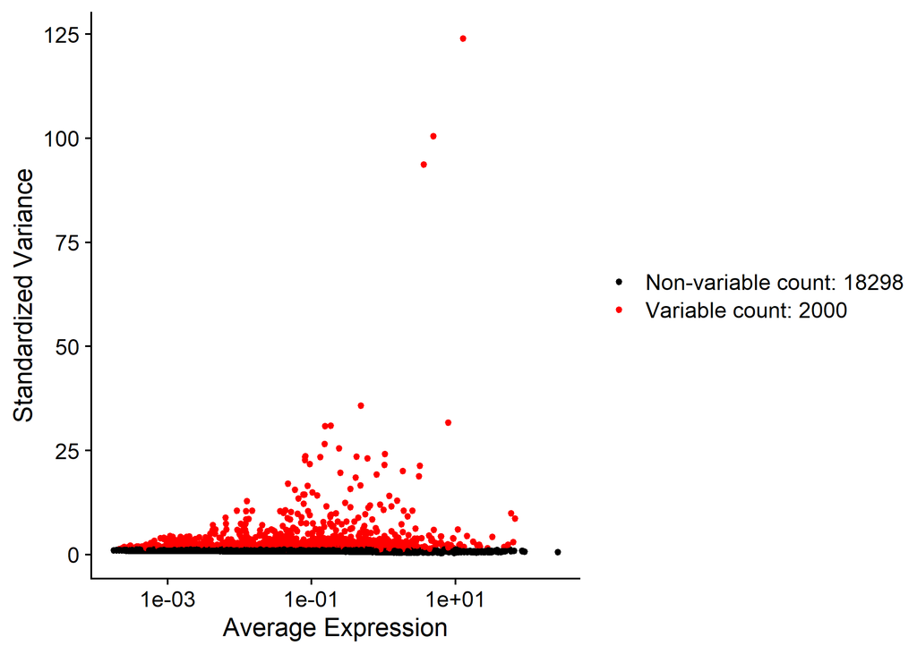

```r
obj <- FindVariableFeatures(obj, selection.method = "vst", nfeatures = 2000)
variable_plot <- VariableFeaturePlot(obj)
save_plot(variable_plot, "variable_features.png", width = 8, height = 5)
variable_plot
```

Highly variable genes were identified to capture the most informative features, focusing downstream analysis on genes with meaningful biological variation.

### Scaling

```r
obj <- ScaleData(obj, features = VariableFeatures(obj))
```

The data were scaled so that expression values for each gene were centred and standardised across cells. This step is important prior to principal component analysis, as it prevents genes with high variance or large absolute expression values from disproportionately influencing dimensionality reduction.

### PCA

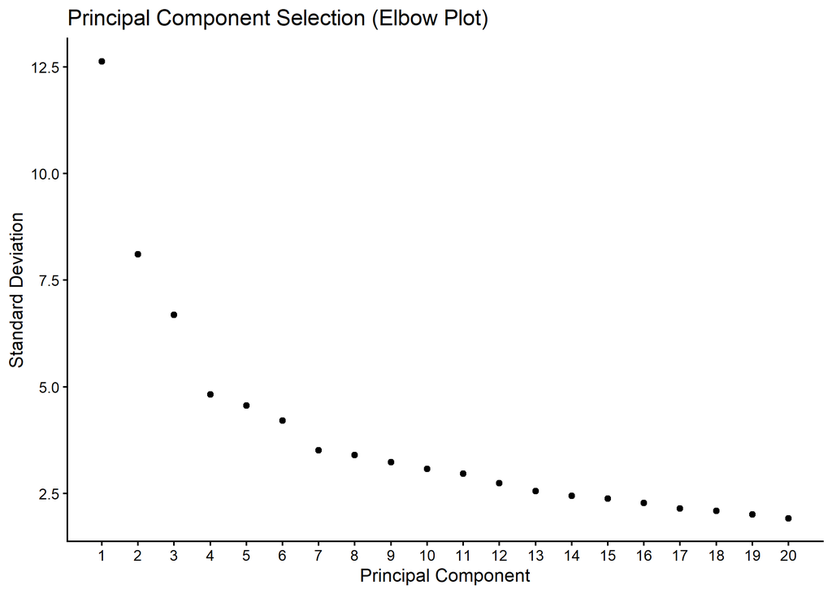

```r
obj <- RunPCA(obj, features = VariableFeatures(obj))
elbow_plot <- ElbowPlot(obj) +
  scale_x_continuous(breaks = 1:20) +
  ggtitle("Principal Component Selection (Elbow Plot)") +
    xlab("Principal Component") +
    ylab("Standard Deviation")  +
    theme_classic()

save_plot(elbow_plot, "elbow_plot.png", width = 7, height = 5)
elbow_plot
```

Principal component analysis (PCA) was performed to reduce dimensionality and summarise the major sources of variation in the dataset. Inspection of the elbow plot indicated that the first six principal components captured the main structured sources of variation in the dataset and were therefore retained for downstream analysis.

### Clustering

```r
obj <- FindNeighbors(obj, dims = 1:6)
obj <- FindClusters(obj, resolution = 0.3)
```

```
## Modularity Optimizer version 1.3.0 by Ludo Waltman and Nees Jan van Eck
##
## Number of nodes: 56736
## Number of edges: 1685593
##
## Running Louvain algorithm...
## Maximum modularity in 10 random starts: 0.9453
## Number of communities: 14
## Elapsed time: 12 seconds
```

Cells were clustered using a graph-based approach implemented in Seurat. A shared nearest neighbour graph was constructed from the selected principal components, and clusters were identified using community detection. This step groups transcriptionally similar cells, allowing putative cell populations or cellular states to be resolved in an unsupervised manner. The clustering resolution was set to 0.3 to generate a moderate level of granularity while avoiding over-fragmentation of the dataset.

### UMAP

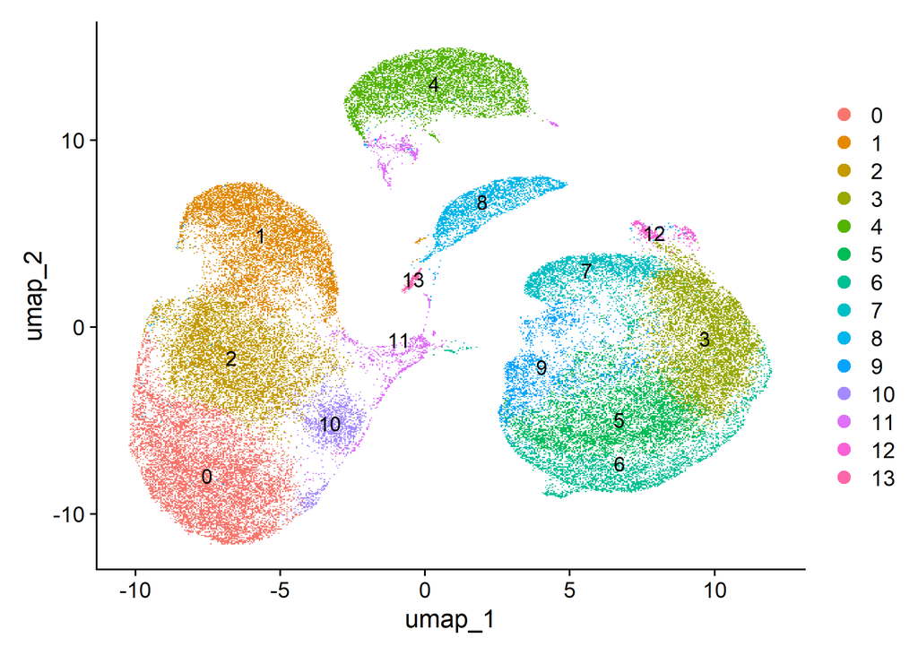

```r
obj <- RunUMAP(obj, dims = 1:6)
umap_clusters <- DimPlot(obj, reduction = "umap", label = TRUE, raster = TRUE)
save_plot(umap_clusters, "umap_clusters.png", width = 8, height = 6)
umap_clusters
```

Uniform Manifold Approximation and Projection (UMAP) was used to visualise the high-dimensional scRNA-seq data in two dimensions. UMAP preserves local structure in the data and allows transcriptionally similar cells to be displayed close together, facilitating interpretation of cluster relationships and population structure.

### Marker Gene Identification

```r
future::plan(multisession, workers = marker_workers)
markers <- FindAllMarkers(
  obj,
  only.pos = TRUE,
  min.pct = 0.25,
  logfc.threshold = 0.25
)
future::plan(sequential)

top5_markers <- markers %>%
  group_by(cluster) %>%
  slice_max(order_by = avg_log2FC, n = 5, with_ties = FALSE) %>%
  ungroup()

head(markers)
```

|  | p_val | avg_log2FC | pct.1 | pct.2 | p_val_adj | cluster | gene |
| --- | --- | --- | --- | --- | --- | --- | --- |
| KLRD1 | 0 | 3.343963 | 0.934 | 0.166 | 0 | 0 | KLRD1 |
| GZMB | 0 | 3.356910 | 0.964 | 0.196 | 0 | 0 | GZMB |
| PRF1 | 0 | 3.157121 | 0.951 | 0.208 | 0 | 0 | PRF1 |
| KLRF1 | 0 | 5.171237 | 0.780 | 0.045 | 0 | 0 | KLRF1 |
| FGFBP2 | 0 | 3.341157 | 0.917 | 0.183 | 0 | 0 | FGFBP2 |
| CTSW | 0 | 3.111901 | 0.955 | 0.247 | 0 | 0 | CTSW |

Marker genes were identified for each cluster using differential expression analysis implemented in Seurat. For each cluster, expression was compared against all remaining cells to identify genes that were significantly upregulated and characteristic of that population. Only positive markers were retained, and minimum expression and fold-change thresholds were applied to prioritise robust and biologically informative genes.

### Top Marker Genes by Cluster

Top five marker genes identified for each cluster.

| cluster | gene | avg_log2FC | pct.1 | p_val_adj |
| --- | --- | --- | --- | --- |
| 0 | KLRF1 | 5.171 | 0.780 | 0 |
| 0 | MYOM2 | 5.120 | 0.400 | 0 |
| 0 | KLRC2 | 5.051 | 0.363 | 0 |
| 0 | AKR1C3 | 4.734 | 0.250 | 0 |
| 0 | KIR3DL2 | 4.523 | 0.258 | 0 |
| 1 | MAL | 6.262 | 0.448 | 0 |
| 1 | LEF1 | 4.489 | 0.400 | 0 |
| 1 | TRABD2A | 4.287 | 0.329 | 0 |
| 1 | CD28 | 4.247 | 0.351 | 0 |
| 1 | AQP3 | 3.846 | 0.325 | 0 |
| 2 | CD8A | 3.032 | 0.639 | 0 |
| 2 | CD8B | 3.032 | 0.559 | 0 |
| 2 | GZMK | 2.953 | 0.464 | 0 |
| 2 | TRGC2 | 2.802 | 0.579 | 0 |
| 2 | A2M-AS1 | 2.746 | 0.264 | 0 |
| 3 | PID1 | 3.918 | 0.298 | 0 |
| 3 | ID1 | 3.198 | 0.511 | 0 |
| 3 | LGALS2 | 2.968 | 0.902 | 0 |
| 3 | C15orf48 | 2.926 | 0.275 | 0 |
| 3 | THBD | 2.877 | 0.288 | 0 |
| 4 | IGHD | 7.759 | 0.756 | 0 |
| 4 | VPREB3 | 7.665 | 0.518 | 0 |
| 4 | CD79A | 7.243 | 0.986 | 0 |
| 4 | TCL1A | 7.172 | 0.496 | 0 |
| 4 | FCRLA | 7.165 | 0.360 | 0 |
| 5 | CYP1B1 | 3.494 | 0.549 | 0 |
| 5 | EGR1 | 3.424 | 0.509 | 0 |
| 5 | MARC1 | 3.257 | 0.343 | 0 |
| 5 | CLEC4D | 3.081 | 0.297 | 0 |
| 5 | PLBD1 | 3.056 | 0.857 | 0 |
| 6 | CXCL2 | 4.290 | 0.455 | 0 |
| 6 | ANKRD22 | 4.269 | 0.295 | 0 |
| 6 | EREG | 3.534 | 0.556 | 0 |
| 6 | RNASE2 | 3.492 | 0.703 | 0 |
| 6 | HP | 3.372 | 0.349 | 0 |
| 7 | CDKN1C | 6.039 | 0.778 | 0 |
| 7 | KNDC1 | 5.380 | 0.254 | 0 |
| 7 | NEURL1 | 4.827 | 0.403 | 0 |
| 7 | C1QA | 4.819 | 0.344 | 0 |
| 7 | CKB | 4.408 | 0.432 | 0 |
| 8 | PTCRA | 9.026 | 0.691 | 0 |
| 8 | TMEM40 | 8.846 | 0.771 | 0 |
| 8 | CLEC1B | 8.738 | 0.711 | 0 |
| 8 | ESAM | 8.686 | 0.557 | 0 |
| 8 | GP9 | 8.606 | 0.845 | 0 |
| 9 | CSF3R | 1.923 | 0.366 | 0 |
| 9 | NAMPT | 1.918 | 0.527 | 0 |
| 9 | AC020656.1 | 1.842 | 0.616 | 0 |
| 9 | PLBD1 | 1.703 | 0.321 | 0 |
| 9 | IFITM3 | 1.697 | 0.538 | 0 |
| 10 | LAG3 | 3.678 | 0.769 | 0 |
| 10 | LAIR2 | 3.486 | 0.806 | 0 |
| 10 | NPDC1 | 3.309 | 0.455 | 0 |
| 10 | ACOT7 | 3.030 | 0.399 | 0 |
| 10 | TRAC | 3.007 | 0.908 | 0 |
| 11 | TYMS | 7.390 | 0.487 | 0 |
| 11 | CDT1 | 7.095 | 0.385 | 0 |
| 11 | BIRC5 | 7.055 | 0.377 | 0 |
| 11 | CCNB2 | 7.019 | 0.258 | 0 |
| 11 | PCLAF | 7.005 | 0.493 | 0 |
| 12 | ENHO | 6.641 | 0.478 | 0 |
| 12 | FCER1A | 6.484 | 0.511 | 0 |
| 12 | CD1C | 5.395 | 0.574 | 0 |
| 12 | CLEC10A | 4.825 | 0.511 | 0 |
| 12 | NDRG2 | 4.610 | 0.494 | 0 |
| 13 | IFIT1B | 11.140 | 0.379 | 0 |
| 13 | EPB42 | 9.657 | 0.502 | 0 |
| 13 | ALAS2 | 9.552 | 0.989 | 0 |
| 13 | GYPB | 9.482 | 0.517 | 0 |
| 13 | TSPO2 | 9.367 | 0.253 | 0 |